# Presentations

Below you find an overview of my presentations.

#### Peer-reviewed conference presentations

- **2024** Wang, W., Hummel, J.T., & Nandhakumar, J. The Nexus of Value Creation and Value Capture: Unravelling Tensions in Digital Platform Dynamics. 84th Annual Meeting of the Academy of Management (Chicago, Ill)
- **2024** Wang, W., Hummel, J.T., & Nandhakumar, J. Sustainable Disruption of Organizational Knowledge: A Case Study on Changing Epistemic Stances in Digital Transformation. 57th Hawaii International Conference on System Sciences
- **2023** Wang, W., Hummel, J.T., & Nandhakumar, J. A Knowledge-based Perspective on Digital Transformation. 83th Annual Meeting of the Academy of Management (Boston, MA)
- **2022** Wang, W., Hummel, J.T., & Nandhakumar, J. Metaverse: An Opportunity for Studying Team Coordination in Extreme Contexts. 13th International Process Symposium (PROS) – Organizing on the Precipice: Process Studies in Extreme Contexts
- **2020** Keeping goals relevant. 36th EGOS Colloquium (Hamburg, DE)
- **2019** How do you know what I need? Defining requirements in developing artificial intelligence for litigation, International Conference on Information Systems 2019 (Munich, DE)
- **2019** What do we have in common? A study on the development of an infrastructure of common resources, 6th Innovation in Information Infrastructures Workshop (Guildford, UK)
- **2019** What do we have in common? A study on the development of an infrastructure of common resources, DigiEra 2019 conference (Monte Verita, CH)
- **2018** Keeping goals relevant in multi-actor collaborations. 78th Annual Meeting of the Academy of Management (Chicago, IL)
- **2018** Keeping goals relevant in multi-actor collaborations. 13th Organization Studies Summer Workshop (Samos, GR)
- **2017** Keeping goals relevant – A study on the collaboration between Big Science and Big Business. Winter Doctoral Conference, Judge Business School (Cambridge, UK)
- **2017** Goal dynamics in interorganizational collaborations. 77th Annual Meeting of the Academy of Management (Atlanta, GA)
- **2017** What do we have in common? The development of common resources in a meta-organization. 77th Annual Meeting of the Academy of Management (Atlanta, GA)
- **2017** Collective action among heterogeneous actors in a meta-organization. 33rd EGOS Colloquium (Copenhagen, DEN)
- **2017** Dimensions of open innovation: A systematic review and comparison of knowledge flows and system architectures. DRUID 17 (New York, NY)
- **2016** Processes of polycentric governance in Helix Nebula. 76th Annual Meeting of the Academy of Management (Anaheim, CA)
- **2016** The development of platform strategies for coopetition in home automation. Strategic Management Society Special Conference 2016 (Rome, IT)
- **2015** How changes in the organizing and managing of meta-organizations contribute to their performance. 75th Annual Meeting of the Academy of Management (Vancouver, BC)
- **2015** Dimensions of openness in innovation processes: Exploring the connection between openness of system architectures and openness of knowledge flows. 31st EGOS Colloquium (Athens, GR)

#### Invited presentations

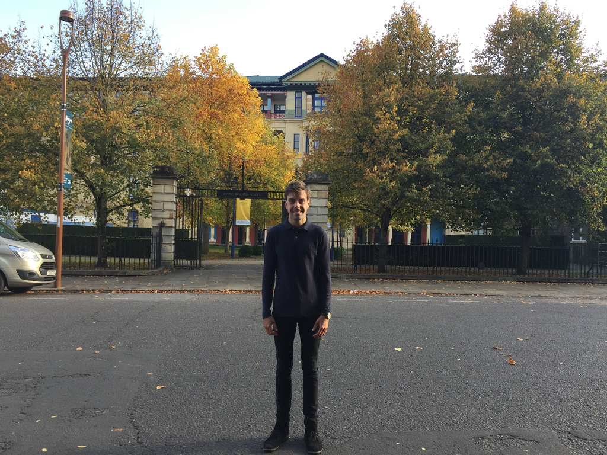